# University of Illinois Survey On Neighborhood Health Analysis

We load all packages that would be required packages that would be needed for the analysis at this step.

We read in the dataset at this stage.The data has 454 rows and 17 columns. We rename the columns with shorther names for easy data manipulation and model building.

```
NAs introduced by coercion
```

```r
head(data)
```

| ID | Gender | Age | Hypertension | Employment | Hispanic | Education | Hispanic_ancestry | race_white | race_black | race_Asian | race_pacific | race_Amer_Indian | race_other | race_dontknow | race_refused | Asian_ancestry |
| --- | --- | --- | --- | --- | --- | --- | --- | --- | --- | --- | --- | --- | --- | --- | --- | --- |
| 1 | Male | 24 | Yes | Self-employed, | No | Bachelor's Degree (Example: BA, AB, BS, BBA) | . | Yes | No | No | No | No | No | No | No | . |
| 2 | Female | 76 | Yes | Primarily retired, or | No | High School Graduate | . | Yes | No | No | No | No | No | No | No | . |
| 3 | Male | 47 | No | Employed for wages, | No | Bachelor's Degree (Example: BA, AB, BS, BBA) | . | Yes | No | No | No | No | No | No | No | . |
| 4 | Female | 42 | No | Employed for wages, | No | Bachelor's Degree (Example: BA, AB, BS, BBA) | . | Yes | No | No | No | No | No | No | No | . |
| 5 | Female | 24 | No | Employed for wages, | No | Bachelor's Degree (Example: BA, AB, BS, BBA) | . | Yes | No | No | No | No | No | No | No | . |
| 6 | Female | 39 | No | Employed for wages, | No | Master's Degree (Example: MA, MS, MENG, MED, MBA) | . | Yes | No | No | No | No | No | No | No | . |

```r
str(data)
```

```
Classes tbl_df, tbl and 'data.frame':   454 obs. of  17 variables:
 $ ID               : int  1 2 3 4 5 6 7 8 9 10 ...
 $ Gender           : chr  "Male" "Female" "Male" "Female" ...
 $ Age              : num  24 76 47 42 24 39 31 25 33 32 ...
 $ Hypertension     : chr  "Yes" "Yes" "No" "No" ...
 $ Employment       : chr  "Self-employed," "Primarily retired, or" "Employed for wages," "Employed for wages," ...
 $ Hispanic         : chr  "No" "No" "No" "No" ...
 $ Education        : chr  "Bachelor's Degree (Example: BA, AB, BS, BBA)" "High School Graduate" "Bachelor's Degree (Example: BA, AB, BS, BBA)" "Bachelor's Degree (Example: BA, AB, BS, BBA)" ...
 $ Hispanic_ancestry: chr  "." "." "." "." ...
 $ race_white       : chr  "Yes" "Yes" "Yes" "Yes" ...
 $ race_black       : chr  "No" "No" "No" "No" ...
 $ race_Asian       : chr  "No" "No" "No" "No" ...
 $ race_pacific     : chr  "No" "No" "No" "No" ...
 $ race_Amer_Indian : chr  "No" "No" "No" "No" ...
 $ race_other       : chr  "No" "No" "No" "No" ...
 $ race_dontknow    : chr  "No" "No" "No" "No" ...
 $ race_refused     : chr  "No" "No" "No" "No" ...
 $ Asian_ancestry   : chr  "." "." "." "." ...
```

Among the Age variable reecorded ,there was 10 reported missing observations.

```r
#==================================================================
#check the number of missing rows
#==================================================================
colSums(is.na.data.frame(data))
```

```
               ID            Gender               Age      Hypertension        Employment          Hispanic
                0                 0                10                10                 0                 0
        Education Hispanic_ancestry        race_white        race_black        race_Asian      race_pacific
                0                 0                 0                 0                 0                 0
 race_Amer_Indian        race_other     race_dontknow      race_refused    Asian_ancestry
                0                 0                 0                 0                10
```

The Asian ancestry variable has a ony 20 reported observations. The remainder are all missing.

```r
data$Asian_ancestry=ifelse(data$Asian_ancestry==".","<NA>",data$Asian_ancestry)
```

We deleted rows for which there was no coded response applicable.Keeping it in the data increases the number of factors in each column.

The character columns is converted to factor levels to be used in the model.

```r
ndata=mutate(ndata,Gender=as.factor(Gender),Age=as.numeric(Age),Hypertension=as.factor(Hypertension),Employment=as.factor(Employment),
       Hispanic=as.factor(Hispanic),Education=as.factor(Education),Hispanic_ancestry=as.factor(Hispanic_ancestry),
       race_white=as.factor(race_white),race_black=as.factor(race_black),race_Asian=as.factor(race_Asian),
       race_pacific=as.factor(race_pacific),race_Amer_Indian=as.factor(race_Amer_Indian),race_other=as.factor(race_other),
       race_dontknow=as.factor(race_dontknow),race_refused=as.factor(race_refused),Asian_ancestry=as.factor(Asian_ancestry) )
```

We explore summary of Hypertension by Age. The median age for those with hypertensive age is 54 whereas the median age for those without hypeertension is 33.

```
Removed 10 rows containing non-finite values (stat_boxplot).
```

[interactive chart not shown]

The median age for female hypertensive poulation 55 is higher than that for male 53. The median age for non hypertensive females 37 is also greater than the males which is 32.

```r
p=ggplot(ndata, aes(x = Hypertension, y = Age, fill = Hypertension)) + geom_boxplot() +
  facet_wrap(~ Gender, ncol = 2)+ggtitle("Age vs Hypertension stratified by Gender")
ggplotly(p)
```

```
Removed 10 rows containing non-finite values (stat_boxplot).
```

[interactive chart not shown]

The age for hypertension stratified by Hispanic race is no different from the rest of the population

```r
p=ggplot(ndata, aes(x = Hypertension, y = Age, fill = Hypertension)) + geom_boxplot() +
  facet_wrap(~ Hispanic, ncol = 2)+ggtitle("Age vs Hypertension stratified by Hispanaic Race")
ggplotly(p)
```

```
Removed 10 rows containing non-finite values (stat_boxplot).
```

[interactive chart not shown]

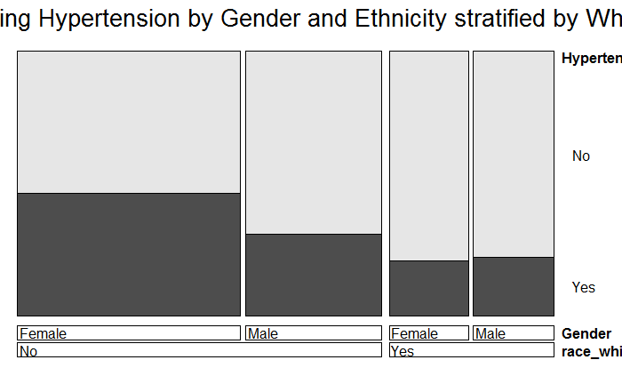

```r
doubledecker(Hypertension ~ race_white + Gender, data=ndata,
             main="Visualizing Hypertension by Gender and Ethnicity stratified by White race")
```

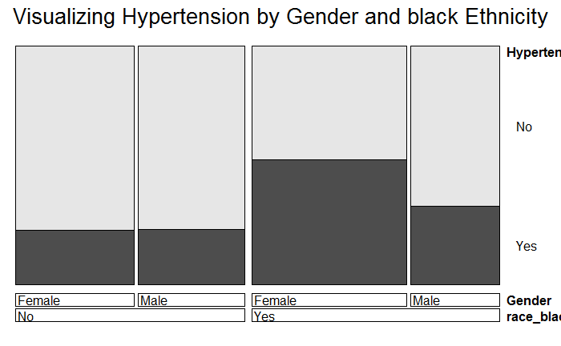

```r
doubledecker(Hypertension ~ race_black + Gender, data=ndata,
             main="Visualizing Hypertension by Gender and black Ethnicity")
```

Model Building

```r
#There is no row with a positive response to race pacific. We do not include this variable in the model.
ndata=ndata%>%dplyr::select(-race_pacific )
index1=sample(1:dim(ndata)[1],replace=F,round(0.7*dim(ndata)[1]))
trainingdata=ndata[index1,]
testdata=ndata[-index1,]
fit<-glm(Hypertension~Gender+Age+Employment+Hispanic+Education+Hispanic_ancestry+race_white+race_black+
           race_Asian+race_Amer_Indian+race_other+race_dontknow+race_refused+Asian_ancestry
         , family = "binomial",data=trainingdata)
both=step(fit, direction = "both",trace=0 )
knitr::kable(tidy(both))
```

| term | estimate | std.error | statistic | p.value |
| --- | --- | --- | --- | --- |
| (Intercept) | 1.6495906 | 2.1158416 | 0.7796380 | 0.4356040 |
| Age | 0.0434993 | 0.0126364 | 3.4423939 | 0.0005766 |
| EmploymentOut of work for less than 1 year, | -1.0377815 | 0.6925763 | -1.4984364 | 0.1340199 |
| EmploymentOut of work for more than 1 year, | 0.2131601 | 0.4845941 | 0.4398736 | 0.6600287 |
| EmploymentPrimarily a homemaker, | -0.1143801 | 0.6332091 | -0.1806356 | 0.8566536 |
| EmploymentPrimarily a student, | 0.2569973 | 0.6845843 | 0.3754064 | 0.7073583 |
| EmploymentPrimarily retired, or | 3.6798312 | 1.2974357 | 2.8362339 | 0.0045649 |
| EmploymentSelf-employed, | -0.4083673 | 0.6531790 | -0.6251996 | 0.5318400 |
| EmploymentUnable to work? | 1.9820486 | 0.6705626 | 2.9557995 | 0.0031186 |
| race_whiteYes | -5.4564313 | 2.0426733 | -2.6712208 | 0.0075576 |
| race_blackYes | -3.7175417 | 1.9911150 | -1.8670653 | 0.0618925 |
| race_Amer_IndianYes | -3.0016048 | 1.4957476 | -2.0067589 | 0.0447753 |
| race_otherYes | -5.0622729 | 2.0156163 | -2.5115261 | 0.0120210 |
| race_dontknowYes | -3.9952023 | 2.2067590 | -1.8104389 | 0.0702277 |
| race_refusedYes | -4.8236388 | 2.8241946 | -1.7079697 | 0.0876420 |
| Asian_ancestryAsian Indian, | -4.5206452 | 2.2635297 | -1.9971663 | 0.0458071 |
| Asian_ancestryChinese, | -19.4890436 | 949.1769558 | -0.0205326 | 0.9836185 |
| Asian_ancestryKorean, or | 13.8289954 | 2399.5455822 | 0.0057632 | 0.9954017 |

```r
glance(both)
```

| null.deviance | df.null | logLik | AIC | BIC | deviance | df.residual |
| --- | --- | --- | --- | --- | --- | --- |
| 396.4978 | 298 | -128.8565 | 293.713 | 360.321 | 257.713 | 281 |

```r
augment(both)
```

| .rownames | Hypertension | Age | Employment | race_white | race_black | race_Amer_Indian | race_other | race_dontknow | race_refused | Asian_ancestry | .fitted | .se.fit | .resid | .hat | .sigma | .cooksd | .std.resid |
| --- | --- | --- | --- | --- | --- | --- | --- | --- | --- | --- | --- | --- | --- | --- | --- | --- | --- |
| 1 | Yes | 53 | Employed for wages, | No | Yes | No | No | No | No |  | 0.237511806 | 0.2783676 | 1.078356e+00 | 0.0191014685 | 0.9571676 | 8.697532e-04 | 1.088805e+00 |
| 2 | Yes | 53 | Unable to work? | No | No | No | Yes | No | No |  | 0.874829251 | 0.7554667 | 8.348591e-01 | 0.1185218297 | 0.9579038 | 3.533208e-03 | 8.892162e-01 |
| 3 | No | 36 | Employed for wages, | No | No | No | Yes | No | No |  | -1.846707492 | 0.5467297 | -5.412641e-01 | 0.0351800660 | 0.9588114 | 3.312201e-04 | -5.510438e-01 |
| 4 | No | 26 | Primarily a homemaker, | No | Yes | No | No | No | No |  | -1.051349371 | 0.6640811 | -7.742207e-01 | 0.0846297751 | 0.9581571 | 1.960929e-03 | -8.092196e-01 |
| 5 | No | 26 | Self-employed, | Yes | No | No | No | No | No |  | -3.084226201 | 0.7445176 | -2.991625e-01 | 0.0231963136 | 0.9592062 | 6.181153e-05 | -3.026938e-01 |
| 6 | No | 21 | Employed for wages, | No | Yes | No | No | No | No |  | -1.154465794 | 0.3758790 | -7.402816e-01 | 0.0257464410 | 0.9583292 | 4.750317e-04 | -7.499995e-01 |
| 7 | Yes | 59 | Employed for wages, | No | Yes | No | No | No | No |  | 0.498507607 | 0.3192696 | 9.743107e-01 | 0.0239634019 | 0.9575647 | 8.488768e-04 | 9.861987e-01 |
| 8 | No | 34 | Employed for wages, | No | Yes | No | No | No | No |  | -0.588974894 | 0.2755492 | -9.395835e-01 | 0.0174263770 | 0.9577029 | 5.564368e-04 | -9.478788e-01 |
| 9 | Yes | 24 | Self-employed, | Yes | No | No | No | No | No |  | -3.171224801 | 0.7520783 | 2.534688e+00 | 0.0218567272 | 0.9470722 | 3.025193e-02 | 2.562850e+00 |
| 10 | No | 45 | Employed for wages, | Yes | No | No | No | No | No |  | -1.849372235 | 0.3784780 | -5.405936e-01 | 0.0168263627 | 0.9588233 | 1.521546e-04 | -5.451999e-01 |

[output cut: 289 more lines]

```r
## CIs using profiled log-likelihood
#fit
suppressWarnings(knitr::kable(confint(both)))
```

|  | 2.5 % | 97.5 % |
| --- | --- | --- |
| (Intercept) | -2.2397590 | 6.3008389 |
| Age | 0.0191117 | 0.0688477 |
| EmploymentOut of work for less than 1 year, | -2.5868714 | 0.2115499 |
| EmploymentOut of work for more than 1 year, | -0.7551177 | 1.1573178 |
| EmploymentPrimarily a homemaker, | -1.4182466 | 1.0944245 |
| EmploymentPrimarily a student, | -1.2017877 | 1.5362902 |
| EmploymentPrimarily retired, or | 1.5970390 | 7.0945719 |
| EmploymentSelf-employed, | -1.7804151 | 0.8211157 |
| EmploymentUnable to work? | 0.7549245 | 3.4408572 |
| race_whiteYes | -10.0134772 | -1.7771168 |
| race_blackYes | -8.1904220 | -0.1327036 |
| race_Amer_IndianYes | -6.6155479 | -0.3292561 |
| race_otherYes | -9.5493853 | -1.4016361 |
| race_dontknowYes | -8.8072361 | 0.0743563 |
| race_refusedYes | -10.6782640 | 0.4755144 |
| Asian_ancestryAsian Indian, | -9.5239835 | -0.4463420 |
| Asian_ancestryChinese, | -375.2216844 | 13.2241875 |
| Asian_ancestryKorean, or | -89.6513115 | 799.2226864 |

```r
## odds ratios only
(exp(coef(both)))
```

```
                                (Intercept)                                         Age
                               5.204848e+00                                1.044459e+00
EmploymentOut of work for less than 1 year, EmploymentOut of work for more than 1 year,
                               3.542397e-01                                1.237583e+00
           EmploymentPrimarily a homemaker,              EmploymentPrimarily a student,
                               8.919189e-01                                1.293042e+00
            EmploymentPrimarily retired, or                    EmploymentSelf-employed,
                               3.963970e+01                                6.647347e-01
                  EmploymentUnable to work?                               race_whiteYes
                               7.257596e+00                                4.268763e-03
                              race_blackYes                         race_Amer_IndianYes
                               2.429362e-02                                4.970723e-02
                              race_otherYes                            race_dontknowYes
                               6.331153e-03                                1.840372e-02
                            race_refusedYes                 Asian_ancestryAsian Indian,
                               8.037487e-03                                1.088200e-02
                     Asian_ancestryChinese,                    Asian_ancestryKorean, or
                               3.435705e-09                                1.013576e+06
```

```r
## odds ratios and 95% CI
suppressWarnings(suppressMessages(knitr::kable(exp(cbind(OR = coef(both), confint(both))))))
```

|  | OR | 2.5 % | 97.5 % |
| --- | --- | --- | --- |
| (Intercept) | 5.204848e+00 | 0.1064842 | 5.450289e+02 |
| Age | 1.044459e+00 | 1.0192955 | 1.071273e+00 |
| EmploymentOut of work for less than 1 year, | 3.542397e-01 | 0.0752551 | 1.235592e+00 |
| EmploymentOut of work for more than 1 year, | 1.237583e+00 | 0.4699553 | 3.181389e+00 |
| EmploymentPrimarily a homemaker, | 8.919189e-01 | 0.2421382 | 2.987463e+00 |
| EmploymentPrimarily a student, | 1.293042e+00 | 0.3006563 | 4.647318e+00 |
| EmploymentPrimarily retired, or | 3.963970e+01 | 4.9383880 | 1.205406e+03 |
| EmploymentSelf-employed, | 6.647347e-01 | 0.1685682 | 2.273034e+00 |
| EmploymentUnable to work? | 7.257596e+00 | 2.1274508 | 3.121370e+01 |
| race_whiteYes | 4.268800e-03 | 0.0000448 | 1.691251e-01 |
| race_blackYes | 2.429360e-02 | 0.0002773 | 8.757246e-01 |
| race_Amer_IndianYes | 4.970720e-02 | 0.0013394 | 7.194588e-01 |
| race_otherYes | 6.331200e-03 | 0.0000712 | 2.461938e-01 |
| race_dontknowYes | 1.840370e-02 | 0.0001496 | 1.077190e+00 |
| race_refusedYes | 8.037500e-03 | 0.0000230 | 1.608842e+00 |
| Asian_ancestryAsian Indian, | 1.088200e-02 | 0.0000731 | 6.399649e-01 |
| Asian_ancestryChinese, | 0.000000e+00 | 0.0000000 | 5.535944e+05 |
| Asian_ancestryKorean, or | 1.013576e+06 | 0.0000000 | Inf |

```r
#==================================================================
#Evaluating Model Fit regression
#==================================================================
st$anova
```

[output not shown]

The godness -of-fit of the overall model is obtained by the Hosmer-Lemeshow Test.

```r
hoslem.test(trainSet$Hypertension, fitted(both), g=10)
```

[output not shown]

```
    Hosmer and Lemeshow goodness of fit (GOF) test

data:  trainSet$Hypertension, fitted(both)
X-squared = 299, df = 8, p-value < 2.2e-16
```

```r
varImp(both)
```

|  | Overall |
| --- | --- |
| Age | 3.442393857 |
| EmploymentOut of work for less than 1 year, | 1.498436367 |
| EmploymentOut of work for more than 1 year, | 0.439873579 |
| EmploymentPrimarily a homemaker, | 0.180635566 |
| EmploymentPrimarily a student, | 0.375406355 |
| EmploymentPrimarily retired, or | 2.836233885 |
| EmploymentSelf-employed, | 0.625199625 |
| EmploymentUnable to work? | 2.955799523 |
| race_whiteYes | 2.671220763 |
| race_blackYes | 1.867065256 |

[output cut: 7 more lines]

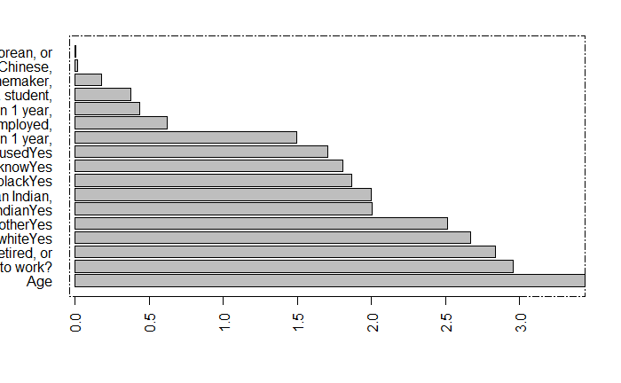

```r
#==================================================================
#Variable Importance Plot
#==================================================================
dat=sort(varImp(both)$Overall,decreasing = T)
importanceOrder=order(-varImp(both)$Overall)
names=rownames(varImp(both))[importanceOrder]
names(dat)=names
barplot(dat,las=2,ylab="",xlab="", horiz=TRUE)
box(lty = '1373', col = 'black')
```

```r
#==================================================================
#Variable Importance Plot
#==================================================================
d=data_frame(varImp(both)$Overall)
row.names(d)
```

```
 [1] "1"  "2"  "3"  "4"  "5"  "6"  "7"  "8"  "9"  "10" "11" "12" "13" "14" "15" "16" "17"
```

```r
p <- plot_ly(
  y = names,
  x = dat,
  name = "",
  type = "bar"
)
p %>%
  layout(title = "Variable Importance Plot",
         xaxis = list(title = ""),
         yaxis = list(title = ""))
```

[interactive chart not shown]

Prediction

```r
# Predict using the test data
newdata3 <- cbind(testSet , predict(both, newdata = testSet , type = "link",
                                    se = TRUE))
newdata3 <- within(newdata3, {
  PredictedProb <- plogis(fit)
  LL <- plogis(fit - (1.96 * se.fit))
  UL <- plogis(fit + (1.96 * se.fit))
})
#knitr::kable((newdata3))
datatable(newdata3)
```

|  | Gender | Age | Hypertension | Employment | Hispanic | Education | Hispanic_ancestry | race_white | race_black | race_Asian | race_pacific | race_Amer_Indian | race_other | race_dontknow | race_refused | Asian_ancestry | fit | se.fit | residual.scale | UL | LL | PredictedProb |
| --- | --- | --- | --- | --- | --- | --- | --- | --- | --- | --- | --- | --- | --- | --- | --- | --- | --- | --- | --- | --- | --- | --- |
| 1 | Female | 25 | No | Primarily a student, | No | Bachelor's Degree (Example: BA, AB, BS, BBA) | . | Yes | No | No | No | No | No | No | No | &lt;NA&gt; | -2.4623609528423 | 0.678876607555261 | 1 | 0.243835928768857 | 0.0220324719620344 | 0.0785393028258802 |
| 2 | Male | 32 | No | Primarily a student, | No | Master's Degree (Example: MA, MS, MENG, MED, MBA) | . | Yes | No | No | No | No | No | No | No | &lt;NA&gt; | -2.15786585278879 | 0.688095205411307 | 1 | 0.308061156874405 | 0.0291269330444855 | 0.103598473211975 |
| 3 | Female | 24 | No | Employed for wages, | No | Bachelor's Degree (Example: BA, AB, BS, BBA) | . | Yes | No | No | No | No | No | No | No | &lt;NA&gt; | -2.76285753497911 | 0.433063781969642 | 1 | 0.128526256505083 | 0.0262967162195501 | 0.0593645988975578 |
| 4 | Male | 31 | No | Employed for wages, | No | Bachelor's Degree (Example: BA, AB, BS, BBA) | . | Yes | No | No | No | No | No | No | No | &lt;NA&gt; | -2.4583624349256 | 0.396395810176106 | 1 | 0.156906649713542 | 0.0378587834268754 | 0.0788291671876404 |
| 5 | Male | 26 | No | Employed for wages, | No | Bachelor's Degree (Example: BA, AB, BS, BBA) | . | Yes | No | No | No | No | No | No | No | &lt;NA&gt; | -2.67585893496382 | 0.421019690028384 | 1 | 0.135795383876559 | 0.0292821558714693 | 0.0644129836522044 |
| 6 | Female | 34 | No | Employed for wages, | No | Doctoral Degree (Example: PHD, EDD) | . | Yes | No | No | No | No | No | No | No | &lt;NA&gt; | -2.32786453490267 | 0.385856360584648 | 1 | 0.171990402714597 | 0.0437661000686724 | 0.0888413744232428 |
| 7 | Male | 31 | No | Employed for wages, | No | Bachelor's Degree (Example: BA, AB, BS, BBA) | . | Yes | No | No | No | No | No | No | No | &lt;NA&gt; | -2.4583624349256 | 0.396395810176106 | 1 | 0.156906649713542 | 0.0378587834268754 | 0.0788291671876404 |
| 8 | Male | 24 | No | Primarily a student, | No | Bachelor's Degree (Example: BA, AB, BS, BBA) | . | No | No | Yes | No | No | No | No | No | Asian Indian, | -1.57007414176775 | 1.17816126657876 | 1 | 0.676803819018437 | 0.020247468961113 | 0.172205822495572 |
| 9 | Male | 47 | No | Employed for wages, | No | Some College, No Degree | . | Yes | No | No | No | No | No | No | No | &lt;NA&gt; | -1.7623736348033 | 0.382585715061344 | 1 | 0.266489780683658 | 0.0750044392641213 | 0.146493307977954 |
| 10 | Female | 31 | Yes | Employed for wages, | No | Bachelor's Degree (Example: BA, AB, BS, BBA) | . | No | No | Yes | No | No | No | No | No | Asian Indian, | -1.52257632384341 | 1.12723275441996 | 1 | 0.665254665286462 | 0.0233860322431064 | 0.179082455871802 |

[output cut: 115 more lines]

This is how our model does on predicting hypertension,For example ,for a person Age 83 and Hypertension=Yes,the model predicts with 92% probability that the person has Hypertension

```r
p=ggplot(newdata3, aes(x = Age, y = PredictedProb,color=Hypertension))+geom_point()+theme_minimal()
ggplotly(p)
```

[interactive chart not shown]

Predicted probablity of hypertension versus observed level of hypertension.

```r
predict <- predict(both,testSet, type = 'response')
hypertesion=if_else(newdata3$Hypertension=="Yes",1,0)
newdata4=newdata3%>%dplyr::mutate(HypertensionN=if_else(Hypertension=="Yes",1,0))
p=ggplot(newdata4, aes(x = HypertensionN, y = PredictedProb))+geom_point()+theme_minimal()
ggplotly(p)
```

[interactive chart not shown]

```r
p <- ggplot(trainSet, aes(d = Hypertension, m = Age)) + geom_roc()+ style_roc()
```

```r
plotata=data.frame(trainSet)
p <- ggplot(plotata, aes(d = Hypertension, m = Age)) + geom_roc()+ style_roc()
#cat(export_interactive_roc(p,  prefix = "a"))
#plot_interactive_roc(p)
cat(
  export_interactive_roc(p,
                        prefix = "a")
  )
```

Scale for ‘x’ is already present. Adding another scale for ‘x’, which will replace the existing scale. Scale for ‘y’ is already present. Adding another scale for ‘y’, which will replace the existing scale.

[figure not shown]

The prediction accuracy of the model is summarized here.The accuracy of prediction is the rate at which the model correctly predicts if a person has hypertension and correctly predicts if they have not.

```r
##  correct predictions rate for test data
#confusion matrix
predict <- predict(both,testSet, type = 'response')
pp=if_else(predict >0.5,"Yes","No")
tab=table(testSet$Hypertension, pp)
(tab[1]+tab[4])/sum(tab)
```

```
[1] 0.784
```

```r
#==================================================================
#confusion matrix
#==================================================================
confusionMatrix(tab)
```

```
Confusion Matrix and Statistics

     pp
      No Yes
  No  69   8
  Yes 19  29

               Accuracy : 0.784
                 95% CI : (0.7015, 0.8526)
    No Information Rate : 0.704
    P-Value [Acc > NIR] : 0.02867

                  Kappa : 0.5228
 Mcnemar's Test P-Value : 0.05429

            Sensitivity : 0.7841
            Specificity : 0.7838
         Pos Pred Value : 0.8961
         Neg Pred Value : 0.6042
             Prevalence : 0.7040
         Detection Rate : 0.5520
   Detection Prevalence : 0.6160
      Balanced Accuracy : 0.7839

       'Positive' Class : No
```

The accuracy of prediction of the model on training data.

```r
##  correct predictions rate for train data
predict1 <- predict(both,trainSet, type = 'response')
pp=if_else(predict1 >0.5,"Yes","No")
tab=table(trainSet$Hypertension, pp)
(tab[1]+tab[4])/sum(tab)
```

```
[1] 0.7658863
```

Comparison of Blood Pressure Levels by Race and Ethnicity(National,from the CDC)

```r
tab <- as.table(matrix(c(43,45.7,27.8,28.9,33.9,31.3,34.1,32.7),4,2,byrow=T))
dimnames(tab) <- list(Race = c("African Americans","Mexican Americans","Whites","All"),
                      Rate  =c("Men(%)","Women(%)") )
tab
```

```
                   Rate
Race                Men(%) Women(%)
  African Americans   43.0     45.7
  Mexican Americans   27.8     28.9
  Whites              33.9     31.3
  All                 34.1     32.7
```

Comparison of Blood Pressure Levels by Race and Ethnicity(Chicago)

```r
tab <- as.table(matrix(c(5.7,15.3,2.1,2.4,3.3,3.5,11.8,23.6),4,2,byrow=T))
dimnames(tab) <- list(Race = c("African Americans","Mexican Americans","Whites","All"),
                      Rate  =c("Men(%)","Women(%)") )
tab
```

```
                   Rate
Race                Men(%) Women(%)
  African Americans    5.7     15.3
  Mexican Americans    2.1      2.4
  Whites               3.3      3.5
  All                 11.8     23.6
```

```r
ndata%>%dplyr::filter(Hypertension=="Yes",race_white=="Yes",Gender=="Female")%>%summarise(count=n())%>%mutate((count/424)*100)%>%mutate((count/424)*100)
```

| count | (count/424) * 100 |
| --- | --- |
| 14 | 3.301887 |

```r
ndata%>%dplyr::filter(Hypertension=="Yes",race_white=="Yes",Gender=="Male")%>%summarise(count=n())%>%mutate((count/424)*100)%>%mutate((count/424)*100)
```

| count | (count/424) * 100 |
| --- | --- |
| 15 | 3.537736 |

```r
ndata%>%dplyr::filter(Hypertension=="Yes",Hispanic=="Yes",Gender=="Male")%>%summarise(count=n())%>%mutate((count/424)*100)%>%mutate((count/424)*100)
```

| count | (count/424) * 100 |
| --- | --- |
| 9 | 2.122642 |

```r
ndata%>%dplyr::filter(Hypertension=="Yes",Hispanic=="Yes",Gender=="Female")%>%summarise(count=n())%>%mutate((count/424)*100)%>%mutate((count/424)*100)
```

| count | (count/424) * 100 |
| --- | --- |
| 10 | 2.358491 |

```r
ndata%>%dplyr::filter(Hypertension=="Yes",Gender=="Female")%>%summarise(count=n())%>%mutate((count/424)*100)
```

| count | (count/424) * 100 |
| --- | --- |
| 100 | 23.58491 |

```r
ndata%>%dplyr::filter(Hypertension=="Yes",Gender=="Male")%>%summarise(count=n())%>%mutate((count/424)*100)
```

| count | (count/424) * 100 |
| --- | --- |
| 50 | 11.79245 |

```r
ndata%>%dplyr::filter(Hypertension=="Yes",race_white=="No",Gender=="Female")%>%summarise(count=n())%>%mutate((count/424)*100)%>%mutate((count/424)*100)
```

| count | (count/424) * 100 |
| --- | --- |
| 86 | 20.28302 |

```r
ndata%>%dplyr::filter(Hypertension=="Yes",race_white=="No",Gender=="Male")%>%summarise(count=n())%>%mutate((count/424)*100)%>%mutate((count/424)*100)
```

| count | (count/424) * 100 |
| --- | --- |
| 35 | 8.254717 |

```r
Race = c("African Americans","Mexican Americans","Whites","All")
Male=c(5.7,2.1,3.3,11.8)
Female=c(15.3,2.4,3.5,23.6)
data=data_frame(Race,Male,Female)
p <- plot_ly(data, x = ~Race, y = ~Male, type = 'bar', name = 'Male') %>%
  add_trace(y = ~Female, name = 'Female') %>%
  layout(yaxis = list(title = 'Percentage'), barmode = 'group')
p
```

[interactive chart not shown]

```r
Race = c("African Americans","Mexican Americans","Whites","All")
Male=c(6.34,2.1,3.3,11.8)
Female=c(17.69,2.4,3.5,23.6)
data=data_frame(Race,Male,Female)
p <- plot_ly(data, x = ~Race, y = ~Male, type = 'bar', name = 'Male') %>%
  add_trace(y = ~Female, name = 'Female') %>%
  layout(yaxis = list(title = 'Count'), barmode = 'group')
p
```

[interactive chart not shown]

```r
#==================================================================
#stacked bar plots
#==================================================================
White<- c("Yes","No")
Male <- c(6.4, 8.3)
Female<- c(17.69, 20.28)
data <- data.frame(White, Female, Male)
p <- plot_ly(data, x = ~White, y = ~Female, type = 'bar', name = 'Female') %>%
  add_trace(y = ~Male, name = 'Male') %>%
  layout(yaxis = list(title = 'Percentage'), barmode = 'stack')%>%
  layout(title = "Percentage of Whites with Hypertension",
         xaxis = list(title = "White"),
         yaxis = list(title = "Percentage"))
p
```

[interactive chart not shown]

```r
White<- c("Yes","No")
Male <- c(6.4, 8.3)
Female<- c(17.69, 20.28)
data <- data.frame(White, Female, Male)
 plot_ly(data, x = ~White, y = ~Female, type = 'bar', name = 'Female') %>%
  add_trace(y = ~Male, name = 'Male')
```

[interactive chart not shown]